# Answer to Question 1

First I load the data into sales variable. I used readr::read_csv as it is usually the faster

```r
sales <- readr::read_csv('2019 winter Data Science Intern Challenge Data Set.csv')
head(sales)
```

| order_id | shop_id | user_id | order_amount | total_items | payment_method | created_at |
| --- | --- | --- | --- | --- | --- | --- |
| 1 | 53 | 746 | 224 | 2 | cash | 2017-03-13 12:36:56 |
| 2 | 92 | 925 | 90 | 1 | cash | 2017-03-03 17:38:52 |
| 3 | 44 | 861 | 144 | 1 | cash | 2017-03-14 4:23:56 |
| 4 | 18 | 935 | 156 | 1 | credit_card | 2017-03-26 12:43:37 |
| 5 | 18 | 883 | 156 | 1 | credit_card | 2017-03-01 4:35:11 |
| 6 | 58 | 882 | 138 | 1 | credit_card | 2017-03-14 15:25:01 |

### part a

First I can calculate AOV by naive average of order_amount, to get 3145.128, which is extremely high for sneakers.

```r
mean(sales$order_amount)
```

[output not shown]

The problem is, there are outliers. From the summary I can see there are extremely large orders.

```r
summary(sales$order_amount)
```

[output not shown]

Order amount histogram chart shows it clearly.

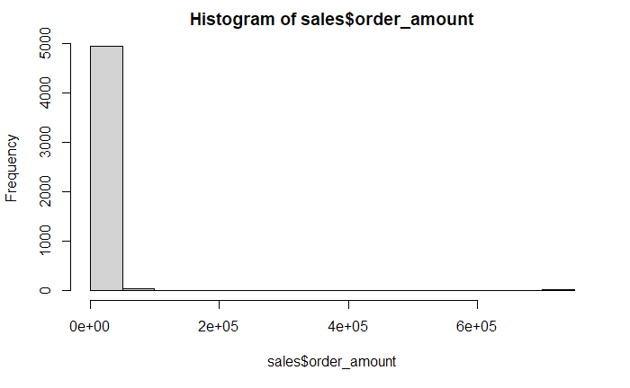

```r
hist(sales$order_amount)
```

The problem is with the large orders from shop 42 and 78.

```r
sales %>% select(shop_id, user_id, order_amount, total_items) %>% unique() %>% arrange(desc(order_amount)) %>% print(n=30)
```

| shop_id | user_id | order_amount | total_items |
| --- | --- | --- | --- |
| 42 | 607 | 704000 | 2000 |
| 78 | 878 | 154350 | 6 |
| 78 | 834 | 102900 | 4 |
| 78 | 775 | 77175 | 3 |
| 78 | 915 | 77175 | 3 |
| 78 | 962 | 77175 | 3 |
| 78 | 817 | 77175 | 3 |
| 78 | 928 | 77175 | 3 |
| 78 | 766 | 77175 | 3 |
| 78 | 787 | 77175 | 3 |

[output cut: 990 more lines]

From the data, one can observe two outlier patterns * there are orders with may items (shop 42, user 607 with 2000 items) * highly priced items (shop 78)

### part b

In this case, we’d better use more robust measures such as median as median would not be impacted by the presence of outliers.

I come up with three possible measures.

Among the three I think b2 would be the best estimate for ‘cheap’ sneakers to ‘ordinary’ buyers.

### part c

1. median order value is $284.

```r
median(sales$order_amount)
```

```
[1] 284
```

2. mean value except for the two shops $300.16

```r
mean(sales$order_amount[ sales$shop_id != 42 & sales$shop_id != 78])
```

```
[1] 300.1558
```

3. first calculate aggregates by shop_id

```r
sales %>% group_by(shop_id) %>%
  summarize(orders = length(order_id), aov = median(order_amount)) -> summary.shop
```

3. median-of-meidans is $306

```r
median(summary.shop$aov)
```

```
[1] 306
```